# Decision Trees v.01

Lazaro Alonso

6/30/2020

## Decision Trees

https://en.wikipedia.org/wiki/Decision_tree_learning Decision tree learning is one of the predictive modelling approaches used in statistics, data mining and machine learning. It uses a decision tree (as a predictive model) to go from observations about an item (represented in the branches) to conclusions about the item’s target value (represented in the leaves). Tree models where the target variable can take a discrete set of values are called classification trees; in these tree structures, leaves represent class labels and branches represent conjunctions of features that lead to those class labels. Decision trees where the target variable can take continuous values (typically real numbers) are called regression trees. Decision trees are among the most popular machine learning algorithms given their intelligibility and simplicity.

In decision analysis, a decision tree can be used to visually and explicitly represent decisions and decision making. In data mining, a decision tree describes data (but the resulting classification tree can be an input for decision making). This page deals with decision trees in data mining.

#### Decision tree types

- **Classification tree** analysis is when the predicted outcome is the class (discrete) to which the data belongs.
- **Regression tree** analysis is when the predicted outcome can be considered a real number (e.g. the price of a house, or a patient’s length of stay in a hospital).

The term Classification And Regression Tree (**CART**) analysis is an umbrella term used to refer to both of the above procedures, first introduced by Breiman et al. in 1984

More than one decision tree: (ensemble methods):

- Boosted trees (AdaBoost)
- Boostrap agregated (bugged)
  - Random forest classifier
- …

#### Trees?

- Nodes:
  - test for the value of a certain attribute
- Edges
  - correspond to the outcome of a test
  - connect to the next node or leaf
- Leaves
  - terminal nodes that predict the outcome

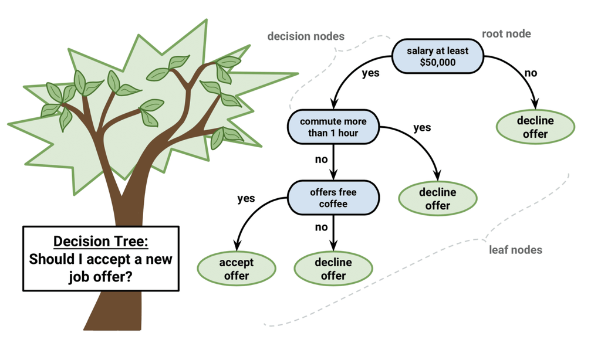

The critical part is how to split ? i.e. The best split.

- Gini impurity (Tsallis Entropy) *[Theory lecture, next session]*
- Information gain (which tell us how well an attribute splits the data) *[Theory lecture, next session]*.

### Some code

##### Getting a tree

Skipping the details about the splitting (for now), this is how we do it with the *tidyverse* suite.

```r
library(tidymodels)
library(rpart)
library(rpart.plot)
```

Let’s play around with some portion of titanic’s tragedy.

```r
data(ptitanic)
ptitanic %>% View()
str(ptitanic)
```

```
'data.frame':   1309 obs. of  6 variables:
 $ pclass  : Factor w/ 3 levels "1st","2nd","3rd": 1 1 1 1 1 1 1 1 1 1 ...
 $ survived: Factor w/ 2 levels "died","survived": 2 2 1 1 1 2 2 1 2 1 ...
 $ sex     : Factor w/ 2 levels "female","male": 1 2 1 2 1 2 1 2 1 2 ...
 $ age     : 'labelled' num  29 0.917 2 30 25 ...
  ..- attr(*, "units")= chr "Year"
  ..- attr(*, "label")= chr "Age"
 $ sibsp   : 'labelled' int  0 1 1 1 1 0 1 0 2 0 ...
  ..- attr(*, "label")= chr "Number of Siblings/Spouses Aboard"
 $ parch   : 'labelled' int  0 2 2 2 2 0 0 0 0 0 ...
  ..- attr(*, "label")= chr "Number of Parents/Children Aboard"
```

```r
model_tree <-
  decision_tree(cost_complexity = 0.004) %>%
  set_engine("rpart") %>%
  set_mode("classification") %>%
  translate()
model_tree
```

```
Decision Tree Model Specification (classification)

Main Arguments:
  cost_complexity = 0.004

Computational engine: rpart

Model fit template:
rpart::rpart(formula = missing_arg(), data = missing_arg(), weights = missing_arg(),
    cp = 0.004)
```

Or we could call directly to **rpart**. See example below.

```r
survived_verse <- model_tree %>%
  fit(survived ~ ., data = ptitanic)
survived_verse
```

```
parsnip model object

Fit time:  30ms
n= 1309

node), split, n, loss, yval, (yprob)
      * denotes terminal node

  1) root 1309 500 died (0.6180290 0.3819710)
    2) sex=male 843 161 died (0.8090154 0.1909846)
      4) age>=9.5 796 136 died (0.8291457 0.1708543) *
      5) age< 9.5 47  22 survived (0.4680851 0.5319149)
       10) sibsp>=2.5 20   1 died (0.9500000 0.0500000) *
       11) sibsp< 2.5 27   3 survived (0.1111111 0.8888889) *
    3) sex=female 466 127 survived (0.2725322 0.7274678)
      6) pclass=3rd 216 106 died (0.5092593 0.4907407)
       12) sibsp>=2.5 21   3 died (0.8571429 0.1428571) *
       13) sibsp< 2.5 195  92 survived (0.4717949 0.5282051)
         26) age>=16.5 162  79 died (0.5123457 0.4876543)
           52) parch>=3.5 9   1 died (0.8888889 0.1111111) *
           53) parch< 3.5 153  75 survived (0.4901961 0.5098039)
            106) age>=27.5 44  17 died (0.6136364 0.3863636) *
            107) age< 27.5 109  48 survived (0.4403670 0.5596330)
              214) age< 21.5 28  11 died (0.6071429 0.3928571) *
              215) age>=21.5 81  31 survived (0.3827160 0.6172840) *
         27) age< 16.5 33   9 survived (0.2727273 0.7272727) *
      7) pclass=1st,2nd 250  17 survived (0.0680000 0.9320000) *
```

Or just using **rpart**.

```r
survived <- rpart(survived ~ ., data = ptitanic, cp = 0.02)
survived
```

```
n= 1309

node), split, n, loss, yval, (yprob)
      * denotes terminal node

 1) root 1309 500 died (0.6180290 0.3819710)
   2) sex=male 843 161 died (0.8090154 0.1909846)
     4) age>=9.5 796 136 died (0.8291457 0.1708543) *
     5) age< 9.5 47  22 survived (0.4680851 0.5319149)
      10) sibsp>=2.5 20   1 died (0.9500000 0.0500000) *
      11) sibsp< 2.5 27   3 survived (0.1111111 0.8888889) *
   3) sex=female 466 127 survived (0.2725322 0.7274678) *
```

```r
# all  the details
summary(survived)
```

```
Call:
rpart(formula = survived ~ ., data = ptitanic, cp = 0.02)
  n= 1309

     CP nsplit rel error xerror       xstd
1 0.424      0     1.000  1.000 0.03515762
2 0.021      1     0.576  0.576 0.02997570
3 0.020      3     0.534  0.574 0.02993826

Variable importance
   sex  sibsp  parch    age pclass
    77      8      7      6      3

Node number 1: 1309 observations,    complexity param=0.424
  predicted class=died      expected loss=0.381971  P(node) =1
    class counts:   809   500
   probabilities: 0.618 0.382
  left son=2 (843 obs) right son=3 (466 obs)
  Primary splits:
      sex    splits as  RL,      improve=172.749200, (0 missing)
      pclass splits as  RRL,     improve= 49.647030, (0 missing)
      parch  < 0.5 to the left,  improve= 18.588590, (0 missing)
      age    < 8.5 to the right, improve=  8.228231, (263 missing)
      sibsp  < 0.5 to the left,  improve=  6.902501, (0 missing)
  Surrogate splits:
      parch < 0.5 to the left,  agree=0.674, adj=0.084, (0 split)

Node number 2: 843 observations,    complexity param=0.021
  predicted class=died      expected loss=0.1909846  P(node) =0.6440031
    class counts:   682   161
   probabilities: 0.809 0.191
  left son=4 (796 obs) right son=5 (47 obs)
  Primary splits:
      age    < 9.5 to the right, improve=13.024220, (185 missing)
      pclass splits as  RLL,     improve=10.198870, (0 missing)
      parch  < 0.5 to the left,  improve= 5.377837, (0 missing)
      sibsp  < 3.5 to the right, improve= 1.101561, (0 missing)
  Surrogate splits:
      sibsp < 3.5 to the left,  agree=0.944, adj=0.14, (185 split)

```

[output cut: 18 more lines]

```
      age    < 3.5 to the right, improve= 0.9085875, (4 missing)
      parch  < 1.5 to the right, improve= 0.4672183, (0 missing)
  Surrogate splits:
      pclass splits as  RRL,     agree=0.723, adj=0.35, (0 split)
      parch  < 1.5 to the right, agree=0.617, adj=0.10, (0 split)

Node number 10: 20 observations
  predicted class=died      expected loss=0.05  P(node) =0.01527884
    class counts:    19     1
   probabilities: 0.950 0.050

Node number 11: 27 observations
  predicted class=survived  expected loss=0.1111111  P(node) =0.02062643
    class counts:     3    24
   probabilities: 0.111 0.889
```

Remember: always ask for help.

```r
?rpart
#?decision_tree
```

And now we can plot the trees (inverted trees actually).

- Another possible way to plot them is by using https://cran.r-project.org/web/packages/ggparty/vignettes/ggparty-graphic-partying.html

### - Option 1.

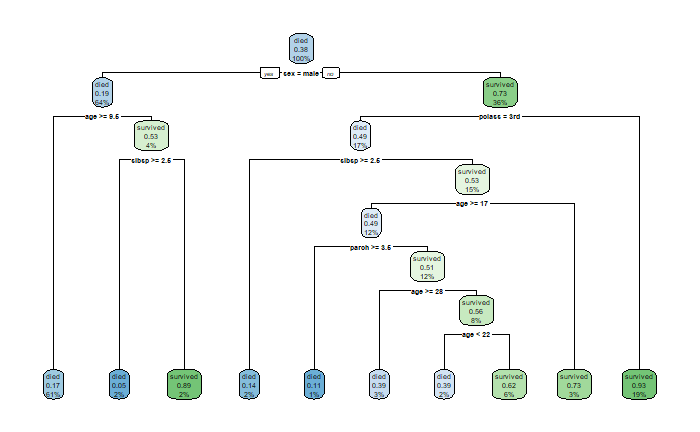

```r
rpart.plot(survived_verse$fit, roundint=FALSE)
```

Each node shows

- the predicted class (died or survived),
- the predicted probability of survival,
- the percentage of observations in the node.

### - Option 2 (with more fine-tunning)

For more info go to http://www.milbo.org/rpart-plot/prp.pdf

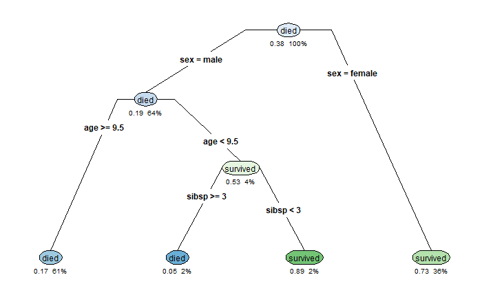

```r
rpart.plot(survived, type = 4, clip.right.labs = FALSE, branch = .3, under = TRUE)
```

What about cp ?? how fast do we reach this treshold.

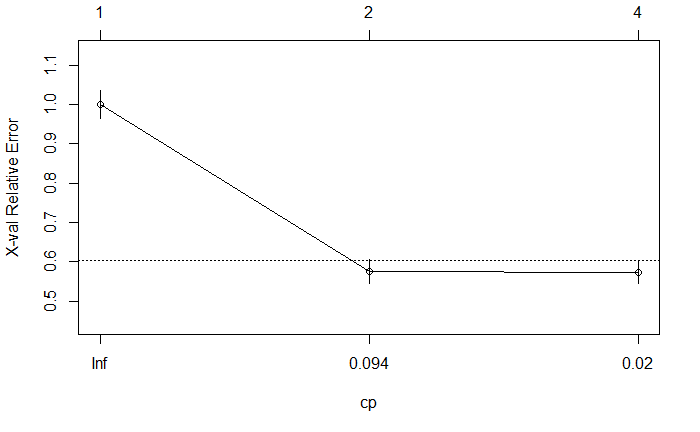

```r
rpart::plotcp(survived)
```

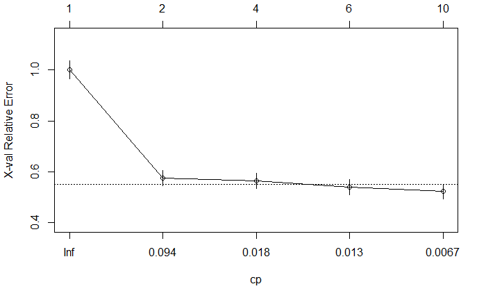

```r
rpart::plotcp(survived_verse$fit)
```

```r
# This looks a little bit different, so it seems that there small differences after all.
```

Play a little bit with this parameter, **cp**, and see how our results change.

```r
ptitanic[1:3,]
```

|  | pclass | survived | sex | age | sibsp | parch |
| --- | --- | --- | --- | --- | --- | --- |
| 1 | 1st | survived | female | 29.0000 | 0 | 0 |
| 2 | 1st | survived | male | 0.9167 | 1 | 2 |
| 3 | 1st | died | female | 2.0000 | 1 | 2 |

```r
rpart.predict(survived, newdata=ptitanic[1:3,], rules=TRUE)
```

| because | sex | is | female |  |  |  |  |  |  |  |  |
| --- | --- | --- | --- | --- | --- | --- | --- | --- | --- | --- | --- |
| because | sex | is | male | & | age | < | 9.5 | & | sibsp | < | 3 |
| because | sex | is | female |  |  |  |  |  |  |  |  |

[output not shown]

- Independet work: work with the **Carseats** dataset, install the **ISLR** package.

Observe that **Sales** is a quantitative variable (show this with a plot). You want to demonstrate it using trees with a binary response. To do so, you turn **Sales** into a binary variable, which will be called High. If the sales is less than 8, it will be not high. Otherwise, it will be high. Then you can put that new variable High back into the dataframe.

- plot
- Activity 2. Obtain the decission tree for the *iris* data set.